# Cox analysis

23 October, 2017

# Objetivos

## OBJETIVO GENERAL

Determinar los factores que intervienen en el pronóstico de sobrevida pulpar de dientes permanentes con desarrollo radicular incompleto que sufren algún tipo de fractura  
coronaria.

## OBJETIVOS ESPECÍFICOS

- Determinar si la presencia de malos hábitos, traumatismos repetidos y control inadecuado de la higiene (por sí solos o asociados) influyen en el pronóstico de sobrevida pulpar de dientes permanentes con desarrollo radicular incompleto que sufren fracturas coronarias.
- Obtener un orden de relevancia de los factores que intervienen en el pronóstico de sobrevida de dientes permanentes con desarrollo radicular incompleto que sufren fracturas coronarias.
- Generar un protocolo de abordaje de dientes permanentes con desarrollo radicular incompleto que sufren fracturas coronarias.

# Paquetes

## Paquetes específicos

```r
library(survival) # for computing survival analyses
library(survminer) # for visualizing survival analysis results
library(ggfortify) # nice plot of survival function
```

# Dataset

```r
df <- read_csv(sprintf("https://docs.google.com/spreadsheets/d/e/2PACX-1vSHQ17f-felEDBHEx2uz0Jjst-_z6wHTfB7hSFHD1iX8XWwd6GYTOYBo5F8DXjLGdxpTk9BqUt_M0lG/pub?gid=1995037555&single=true&output=csv"))
glimpse(df)
```

```
Observations: 106
Variables: 19
$ Marca temporal                        <chr> "4/...
$ HC                                    <int> 26,...
$ ID (nº registro)                      <int> 1, ...
$ GÉNERO                                <chr> "Ma...
$ FECHA DE NACIMIENTO                   <chr> "25...
$ DIENTE AFECTADO                       <int> 11,...
$ DIAGNÓSTICO                           <chr> "FC...
$ SOBREVIDA PULPAR                      <chr> "De...
$ TRATAMIENTO                           <chr> "Re...
$ TIEMPO HASTA LA ATENCIÓN (en horas)   <chr> "16...
$ FECHA TRAUMATISMO                     <chr> "2/...
$ FECHA SOBREVIDA                       <chr> "16...
$ ESTADO RADICULAR INICIAL              <chr> "5 ...
$ TRAUMATISMO REPETIDO                  <chr> "Sí...
$ TRAUMATISMO PREVIO                    <chr> "No...
$ INDICACIÓN DE HIGIENE                 <chr> "To...
$ EVALUACIÓN DE HIGIENE                 <chr> "Re...
$ ONICOFAGIA - INTERPOSICIÓN DE OBJETOS <chr> "No...
$ Evento                                <chr> NA,...
```

## Data manipulation

Creo una nueva variable: status

Pronóstico pulpar: Variable dependiente. Evaluado con radiografía periapical. - **Buen pronóstico**: (PS) sobrevivencia de la Pulpa  
- Sin cambio radiográfico, signos clínicos de vitalidad pulpar. - PCO: obliteración del conducto pulpar. - Detención del crecimiento radicular, conducto pulpar normal, longitud  
radicular disminuida en comparación con el homólogo.

- **Mal pronóstico**: (PN) necrosis pulpar, observando amplitud del conducto radicular, espesor disminuido de paredes radiculares con o sin lesión apical - Desarrollo radicular completo, con tratamiento de endodoncia. - Detención del crecimiento radicular, con tratamiento de endodoncia.

Entonces

**Sobrevida si** - PCO - Detención crecimiento radicular, pulpa vital - Sin cambio rx

**Sobrevida no** - Desarrollo Radicular completo, con endodoncia - Detención crecimiento radicular, con endodoncia

## Variables importantes

- tiempo
- evento
- independientes

### Tiempo

```r
df <- df %>%
  mutate(
    `FECHA TRAUMATISMO` = dmy(`FECHA TRAUMATISMO`),
    `FECHA SOBREVIDA` = dmy(`FECHA SOBREVIDA`),
    `FECHA DE NACIMIENTO` = dmy(`FECHA DE NACIMIENTO`)
  )
# creo time y edad
df <- df %>%
  mutate(
    time = difftime(`FECHA SOBREVIDA`, `FECHA TRAUMATISMO`, units = "weeks") / 52.25,
    edad =  difftime(`FECHA TRAUMATISMO`, `FECHA DE NACIMIENTO`, units = "weeks")/52.25 # edad en años
  )
```

### Eventos

Creo una nueva variable que será el **evento** = 1 (si) en caso que haya algo negativo y no (0) en caso que no haya pasado nada malo

```r
df <-  df %>%
  mutate(
    Evento = case_when(
      `SOBREVIDA PULPAR` == "PCO" |
        `SOBREVIDA PULPAR` == "Detención crecimiento radicular, pulpa vital" |
        `SOBREVIDA PULPAR` == "Sin cambio rx" ~ 0,
      TRUE ~ 1
    )
  )
```

Veo cuantos eventos hay

```r
table(df$Evento)
```

```
 0  1
72 34
```

## Dataset clean

CORREGIDO Hay dos valores negativos, mientras los elimino

which(df$time > 0) df[df$time < 0, ] # ubico a la que es menor df$time df[df$time < 1, ] df <- df[-c(65), ] # elimino la 65 mientras tanto VERIFICAR!!!!

which(df$edad < 0) df[df$edad < 1, ] # hay uno que tiene edad negativa, verificar, mientras lo saco del análisis df <- df[-c(77), ]

```r
summary(df)
```

```
 Marca temporal           HC         ID (nº registro)    GÉNERO          FECHA DE NACIMIENTO
 Length:106         Min.   :  23.0   Min.   :  1.00   Length:106         Min.   :1980-10-25
 Class :character   1st Qu.: 357.0   1st Qu.: 27.25   Class :character   1st Qu.:1985-08-06
 Mode  :character   Median : 597.0   Median : 53.50   Mode  :character   Median :1988-01-25
                    Mean   : 799.9   Mean   : 53.63                      Mean   :1989-12-12
                    3rd Qu.:1206.0   3rd Qu.: 79.75                      3rd Qu.:1993-01-31
                    Max.   :2203.0   Max.   :106.00                      Max.   :2005-07-20
 DIENTE AFECTADO DIAGNÓSTICO        SOBREVIDA PULPAR   TRATAMIENTO
 Min.   :11.00   Length:106         Length:106         Length:106
 1st Qu.:11.00   Class :character   Class :character   Class :character
 Median :21.00   Mode  :character   Mode  :character   Mode  :character
 Mean   :16.31
 3rd Qu.:21.00
 Max.   :41.00
 TIEMPO HASTA LA ATENCIÓN (en horas) FECHA TRAUMATISMO    FECHA SOBREVIDA
 Length:106                          Min.   :1989-01-20   Min.   :1989-09-23
 Class :character                    1st Qu.:1994-03-30   1st Qu.:1998-11-08
 Mode  :character                    Median :1996-06-02   Median :2001-12-22
                                     Mean   :1998-04-08   Mean   :2002-09-11
                                     3rd Qu.:2001-05-06   3rd Qu.:2005-05-20
                                     Max.   :2013-10-09   Max.   :2017-08-02
 ESTADO RADICULAR INICIAL TRAUMATISMO REPETIDO TRAUMATISMO PREVIO INDICACIÓN DE HIGIENE
 Length:106               Length:106           Length:106         Length:106
 Class :character         Class :character     Class :character   Class :character
 Mode  :character         Mode  :character     Mode  :character   Mode  :character



 EVALUACIÓN DE HIGIENE ONICOFAGIA - INTERPOSICIÓN DE OBJETOS     Evento           time
 Length:106            Length:106                            Min.   :0.0000   Length:106
 Class :character      Class :character                      1st Qu.:0.0000   Class :difftime
 Mode  :character      Mode  :character                      Median :0.0000   Mode  :numeric
                                                             Mean   :0.3208
                                                             3rd Qu.:1.0000
                                                             Max.   :1.0000
     edad
 Length:106
 Class :difftime
 Mode  :numeric
```

# Survival analysis

Creo el objeto estándar de sobrevida

```r
km <-  with(df, Surv(time, Evento == 1))
head(km, 50)
```

```
 [1]  9.77443609  14.92822967+  2.57006152
 [4]  8.41285031+  8.41285031+  8.40191388+
 [7]  0.06561859   6.69036227   6.69036227+
[10]  8.01913876+  0.68899522   0.71907040
[13]  1.41353383   8.91592618   0.13943951
[16]  0.13943951   1.77990431+  2.64388243+
[19]  8.60970608+  8.60970608   8.37183869+
[22]  3.96992481   6.79699248+  0.44839371
[25]  6.49077239+  6.04784689+ 14.05878332+
[28]  2.70676692+  8.07382092   2.68489405+
[31]  7.57074504+  0.11756664   0.17498291
[34]  1.53383459   1.99589884+  0.17498291
[37]  2.50991114   0.88038278+  4.71907040+
[40]  8.50307587  10.57826384+  7.37662338+
[43]  7.37662338+  9.41626794+ 12.07928913+
[46]  9.85919344   3.05946685+  0.73000684
[49]  0.73000684+  1.99043062+
```

## Análisis de Kaplan Meier

Ahora el análisis de KM

```r
km_fit <- survfit(Surv(time, Evento) ~ 1, data = df)
summary(km_fit)
```

```
Call: survfit(formula = Surv(time, Evento) ~ 1, data = df)

   time n.risk n.event survival std.err lower 95% CI
 0.0656    106       1    0.991 0.00939        0.972
 0.1176    105       1    0.981 0.01322        0.956
 0.1394    104       2    0.962 0.01851        0.927
 0.1750    102       2    0.943 0.02244        0.900
 0.2925    100       1    0.934 0.02412        0.888
 0.3964     99       1    0.925 0.02566        0.876
 0.3992     98       2    0.906 0.02839        0.852
 0.4484     96       1    0.896 0.02962        0.840
 0.6890     95       1    0.887 0.03077        0.828
 0.7191     94       1    0.877 0.03186        0.817
 0.7300     93       1    0.868 0.03289        0.806
 1.1839     88       1    0.858 0.03396        0.794
 1.3342     87       1    0.848 0.03497        0.782
 1.4135     86       1    0.838 0.03593        0.771
 1.5338     85       1    0.828 0.03683        0.759
 1.8127     82       1    0.818 0.03775        0.748
 1.8346     81       1    0.808 0.03861        0.736
 2.5099     71       1    0.797 0.03971        0.723
 2.5701     69       1    0.785 0.04078        0.709
 2.8872     62       1    0.773 0.04204        0.695
 3.7867     51       1    0.758 0.04386        0.676
 3.9699     50       1    0.742 0.04553        0.658
 4.2433     49       1    0.727 0.04705        0.641
 4.6124     46       1    0.711 0.04861        0.622
 6.6904     26       1    0.684 0.05389        0.586
 8.0738     19       1    0.648 0.06193        0.537
 8.5031     14       1    0.602 0.07277        0.475
 8.6097     13       1    0.555 0.08056        0.418
 8.9159     10       1    0.500 0.08963        0.352
 9.7744      7       1    0.429 0.10136        0.270
 9.8592      6       1    0.357 0.10670        0.199
 upper 95% CI
        1.000
        1.000
        0.999
        0.988
        0.982
```

[output cut: 11 more lines]

```
        0.888
        0.879
        0.869
        0.860
        0.849
        0.837
        0.826
        0.813
        0.798
        0.782
        0.763
        0.738
        0.710
        0.681
        0.641
```

Estos datos se leen de la siguiente manera:

- en la columna time aparece el tiempo. Este es el eje X del gráfico;
- en n.risk el n de individuos en riesgo;
- en n.event la cantidad de eventos en ese período;
- en survival la función de sobrevida. Corresponde al eje Y del gráfico;
- luego el error std y los intervalos de confianza, que aparecen marcados en tono gris.

```r
km_fit
```

```
Call: survfit(formula = Surv(time, Evento) ~ 1, data = df)

      n  events  median 0.95LCL 0.95UCL
 106.00   34.00    8.92    8.50      NA
```

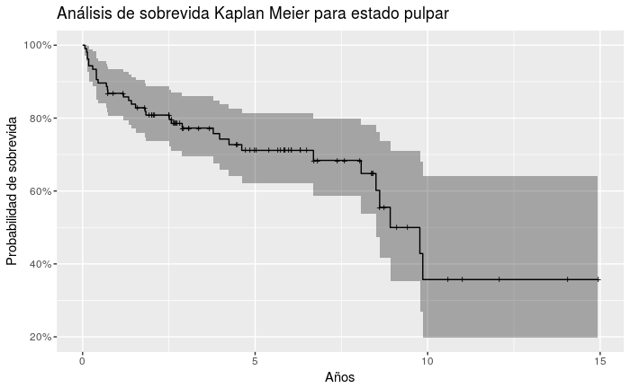

```r
autoplot(km_fit,
         main = "Análisis de sobrevida Kaplan Meier para estado pulpar",
         xlab = "Años", ylab = "Probabilidad de sobrevida")
```

Ahora examino por algunas variables: sexo, dgo del trauma

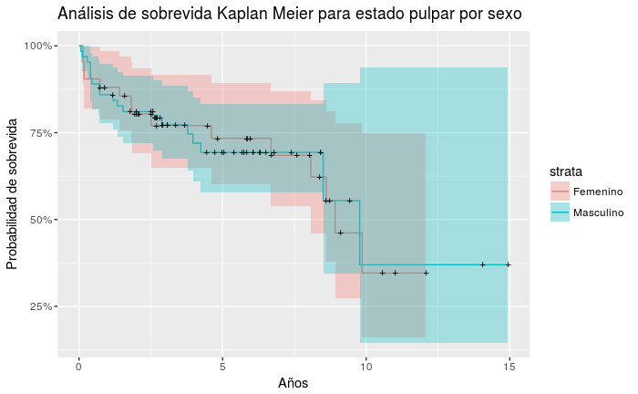

```r
autoplot(
  survfit(Surv(time, Evento) ~ GÉNERO, data = df),
         main = "Análisis de sobrevida Kaplan Meier para estado pulpar por sexo",
         xlab = "Años", ylab = "Probabilidad de sobrevida"
)
```

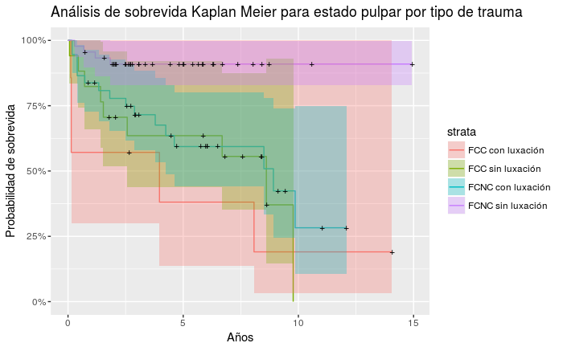

```r
autoplot(
  survfit(Surv(time, Evento) ~ DIAGNÓSTICO, data = df),
          main = "Análisis de sobrevida Kaplan Meier para estado pulpar por tipo de trauma",
         xlab = "Años", ylab = "Probabilidad de sobrevida"
)
```

## Análisis de Cox

El propósito del modelo de Cox es evaluar simultáneamente el efecto de varios factores en la supervivencia. Nos permite examinar cómo diversos influyen en la tasa de un evento en particular que ocurre (por ejemplo, infección, muerte) en un momento particular. Esta tasa se conoce comúnmente como la tasa de riesgo (hazard rate). Las variables (o factores) del predictor generalmente se denominan covariables en la literatura de análisis de supervivencia.

donde,

El modelo de Cox se puede escribir como una regresión lineal múltiple del logaritmo del peligro en las variables xixi, con el riesgo de la línea de base como un término de “intercepción” que varía con el tiempo.

Las cantidades exp (bi) exp (bi) se denominan relaciones de riesgo (HR). Un valor de bibi mayor que cero, o equivalente a una razón de riesgo mayor que uno, indica que a medida que el valor de la novena covariable aumenta, el riesgo de evento aumenta y, por lo tanto, la duración de la supervivencia disminuye.

Dicho de otra manera, una razón de riesgo superior a 1 indica una covariable que está asociada positivamente con la probabilidad del evento y, por lo tanto, está asociada negativamente con la duración de la supervivencia.

En resumen,

HR = 1: sin efecto HR < 1: reducción en el riesgo HR > 1: aumento de riesgo

```r
res.cox1 <- coxph(km ~
                    edad +
                    `DIENTE AFECTADO` +
                    GÉNERO +
                    DIAGNÓSTICO +
                    `TRAUMATISMO REPETIDO` +
                    `TRAUMATISMO PREVIO`,
                  data =  df)
```

Chequeo por si se viola el riesgo proporcional (constante HR en el tiempo)

```r
(res.zph1 <- cox.zph(res.cox1))
```

```
                                 rho  chisq      p
edad                         -0.2823 4.1555 0.0415
`DIENTE AFECTADO`             0.0253 0.0328 0.8562
GÉNEROMasculino              -0.0227 0.0204 0.8865
DIAGNÓSTICOFCC sin luxación   0.2086 1.4959 0.2213
DIAGNÓSTICOFCNC con luxación  0.1858 1.1975 0.2738
DIAGNÓSTICOFCNC sin luxación  0.0254 0.0192 0.8898
`TRAUMATISMO REPETIDO`Sí      0.1465 0.6010 0.4382
`TRAUMATISMO PREVIO`Sí        0.1004 0.3468 0.5559
GLOBAL                            NA 8.0799 0.4257
```

Ahora examino con detalle el modelo de Cox

```r
summary(res.cox1)
```

```
Call:
coxph(formula = km ~ edad + `DIENTE AFECTADO` + GÉNERO + DIAGNÓSTICO +
    `TRAUMATISMO REPETIDO` + `TRAUMATISMO PREVIO`, data = df)

  n= 106, number of events= 34

                                   coef  exp(coef)
edad                          0.4936637  1.6383075
`DIENTE AFECTADO`            -0.0005883  0.9994119
GÉNEROMasculino              -0.0702195  0.9321892
DIAGNÓSTICOFCC sin luxación  -0.9429940  0.3894600
DIAGNÓSTICOFCNC con luxación -0.9640142  0.3813590
DIAGNÓSTICOFCNC sin luxación -2.9324278  0.0532676
`TRAUMATISMO REPETIDO`Sí      0.3278319  1.3879556
`TRAUMATISMO PREVIO`Sí       -0.8109280  0.4444454
                               se(coef)      z
edad                          0.2128762  2.319
`DIENTE AFECTADO`             0.0334896 -0.018
GÉNEROMasculino               0.3994768 -0.176
DIAGNÓSTICOFCC sin luxación   0.6114699 -1.542
DIAGNÓSTICOFCNC con luxación  0.5624577 -1.714
DIAGNÓSTICOFCNC sin luxación  0.7566132 -3.876
`TRAUMATISMO REPETIDO`Sí      0.4073406  0.805
`TRAUMATISMO PREVIO`Sí        0.5409465 -1.499
                             Pr(>|z|)
edad                         0.020394 *
`DIENTE AFECTADO`            0.985985
GÉNEROMasculino              0.860468
DIAGNÓSTICOFCC sin luxación  0.123031
DIAGNÓSTICOFCNC con luxación 0.086541 .
DIAGNÓSTICOFCNC sin luxación 0.000106 ***
`TRAUMATISMO REPETIDO`Sí     0.420929
`TRAUMATISMO PREVIO`Sí       0.133850
---
Signif. codes:
0 ‘***’ 0.001 ‘**’ 0.01 ‘*’ 0.05 ‘.’ 0.1 ‘ ’ 1

                             exp(coef) exp(-coef)
edad                           1.63831     0.6104
`DIENTE AFECTADO`              0.99941     1.0006
GÉNEROMasculino                0.93219     1.0727
DIAGNÓSTICOFCC sin luxación    0.38946     2.5677
DIAGNÓSTICOFCNC con luxación   0.38136     2.6222
DIAGNÓSTICOFCNC sin luxación   0.05327    18.7732
`TRAUMATISMO REPETIDO`Sí       1.38796     0.7205
`TRAUMATISMO PREVIO`Sí         0.44445     2.2500
                             lower .95 upper .95
edad                           1.07943    2.4865
`DIENTE AFECTADO`              0.93592    1.0672
GÉNEROMasculino                0.42606    2.0396
DIAGNÓSTICOFCC sin luxación    0.11748    1.2911
DIAGNÓSTICOFCNC con luxación   0.12664    1.1484
DIAGNÓSTICOFCNC sin luxación   0.01209    0.2347
`TRAUMATISMO REPETIDO`Sí       0.62466    3.0839
`TRAUMATISMO PREVIO`Sí         0.15394    1.2831

Concordance= 0.757  (se = 0.056 )
Rsquare= 0.214   (max possible= 0.924 )
Likelihood ratio test= 25.51  on 8 df,   p=0.001272
Wald test            = 20.65  on 8 df,   p=0.008149
Score (logrank) test = 24.76  on 8 df,   p=0.00171
```

¿Cuanto?

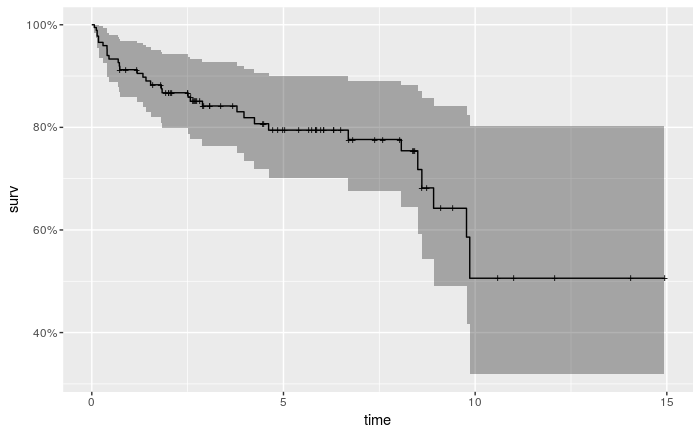

```r
cox_fit <- survfit(res.cox1)
autoplot(cox_fit)
```

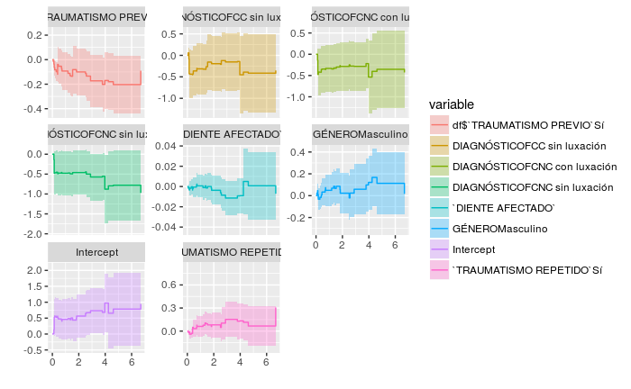

```r
aa_fit <-aareg(Surv(time, Evento) ~
                 `DIENTE AFECTADO` +
                    GÉNERO +
                    DIAGNÓSTICO +
                    `TRAUMATISMO REPETIDO` +
                    df$`TRAUMATISMO PREVIO`,
                  data =  df)
autoplot(aa_fit)
```

### TODOS

```r
modelo_0 <- coxph(km ~
                    df$GÉNERO +
                    df$`DIENTE AFECTADO` +
                    df$DIAGNÓSTICO +
                    df$TRATAMIENTO +
                    # df$`TIEMPO HASTA LA ATENCIÓN (en horas)` +
                    df$`ESTADO RADICULAR INICIAL` +
                    df$`TRAUMATISMO REPETIDO` +
                    df$`TRAUMATISMO PREVIO` +
                    df$`INDICACIÓN DE HIGIENE` +
                    df$`EVALUACIÓN DE HIGIENE` +
                    df$`ONICOFAGIA - INTERPOSICIÓN DE OBJETOS` ,
                  data =  df)
```

```
Loglik converged before variable  7,8,9,10,11,17 ; beta may be infinite.
```

```r
summary(modelo_0)
```

```
Call:
coxph(formula = km ~ df$GÉNERO + df$`DIENTE AFECTADO` + df$DIAGNÓSTICO +
    df$TRATAMIENTO + df$`ESTADO RADICULAR INICIAL` + df$`TRAUMATISMO REPETIDO` +
    df$`TRAUMATISMO PREVIO` + df$`INDICACIÓN DE HIGIENE` + df$`EVALUACIÓN DE HIGIENE` +
    df$`ONICOFAGIA - INTERPOSICIÓN DE OBJETOS`, data = df)

  n= 104, number of events= 34
   (2 observations deleted due to missingness)

                                                                   coef  exp(coef)   se(coef)
df$GÉNEROMasculino                                            1.178e+00  3.248e+00  6.015e-01
df$`DIENTE AFECTADO`                                         -5.115e-02  9.501e-01  3.383e-02
df$DIAGNÓSTICOFCC sin luxación                               -2.046e+00  1.292e-01  1.037e+00
df$DIAGNÓSTICOFCNC con luxación                              -2.000e+00  1.353e-01  1.222e+00
df$DIAGNÓSTICOFCNC sin luxación                              -4.204e+00  1.494e-02  1.330e+00
df$TRATAMIENTOPulido de Fractura                             -8.588e-01  4.237e-01  2.652e+04
df$TRATAMIENTOPulpectomía                                     1.918e+01  2.135e+08  1.001e+04
df$TRATAMIENTOPulpotomía parcial                              1.596e+01  8.536e+06  1.001e+04
df$TRATAMIENTORecubrimiento directo                           1.630e+01  1.204e+07  1.001e+04
df$TRATAMIENTOReposición de fragmento                         1.683e+01  2.042e+07  1.001e+04
df$TRATAMIENTORestauración de composite                       1.696e+01  2.312e+07  1.001e+04
df$`ESTADO RADICULAR INICIAL`5 raíz completa ápice abierto    4.300e-01  1.537e+00  5.083e-01
df$`ESTADO RADICULAR INICIAL`6 raíz completa ½ ápice abierto  2.873e-01  1.333e+00  6.494e-01
df$`TRAUMATISMO REPETIDO`Sí                                   5.217e-02  1.054e+00  5.280e-01
df$`TRAUMATISMO PREVIO`Sí                                    -1.209e+00  2.986e-01  6.678e-01
df$`INDICACIÓN DE HIGIENE`No consignado en ficha clínica      6.679e-01  1.950e+00  8.537e-01
df$`INDICACIÓN DE HIGIENE`Sólo en la primera sesión          -1.887e+01  6.355e-09  8.863e+03
df$`INDICACIÓN DE HIGIENE`Todos los controles                -1.088e+00  3.368e-01  5.786e-01
df$`EVALUACIÓN DE HIGIENE`Mala                                1.404e+00  4.071e+00  7.397e-01
df$`EVALUACIÓN DE HIGIENE`Regular                            -4.523e-01  6.362e-01  6.823e-01
df$`ONICOFAGIA - INTERPOSICIÓN DE OBJETOS`Sí                  6.327e-01  1.883e+00  5.862e-01
                                                                  z Pr(>|z|)
df$GÉNEROMasculino                                            1.959  0.05015 .
df$`DIENTE AFECTADO`                                         -1.512  0.13052
df$DIAGNÓSTICOFCC sin luxación                               -1.973  0.04854 *
df$DIAGNÓSTICOFCNC con luxación                              -1.636  0.10181
df$DIAGNÓSTICOFCNC sin luxación                              -3.160  0.00158 **
df$TRATAMIENTOPulido de Fractura                              0.000  0.99997
df$TRATAMIENTOPulpectomía                                     0.002  0.99847
df$TRATAMIENTOPulpotomía parcial                              0.002  0.99873
```

[output cut: 51 more lines]

```
df$`ESTADO RADICULAR INICIAL`6 raíz completa ½ ápice abierto    4.7596
df$`TRAUMATISMO REPETIDO`Sí                                     2.9656
df$`TRAUMATISMO PREVIO`Sí                                       1.1052
df$`INDICACIÓN DE HIGIENE`No consignado en ficha clínica       10.3923
df$`INDICACIÓN DE HIGIENE`Sólo en la primera sesión                Inf
df$`INDICACIÓN DE HIGIENE`Todos los controles                   1.0466
df$`EVALUACIÓN DE HIGIENE`Mala                                 17.3505
df$`EVALUACIÓN DE HIGIENE`Regular                               2.4228
df$`ONICOFAGIA - INTERPOSICIÓN DE OBJETOS`Sí                    5.9394

Concordance= 0.813  (se = 0.056 )
Rsquare= 0.447   (max possible= 0.927 )
Likelihood ratio test= 61.52  on 21 df,   p=7.493e-06
Wald test            = 47.31  on 21 df,   p=0.0008529
Score (logrank) test = 103.6  on 21 df,   p=6.636e-13
```

### TRAUMATISMO PREVIO

#### modelo 1

#### modelo 1.1 traumatismo repetido por si solo

```r
summary(modelo_1.1)
```

```
Call:
coxph(formula = km ~ df$`TRAUMATISMO REPETIDO`, data = df)

  n= 106, number of events= 34

                               coef exp(coef) se(coef)      z Pr(>|z|)
df$`TRAUMATISMO REPETIDO`Sí -0.2386    0.7878   0.3501 -0.681    0.496

                            exp(coef) exp(-coef) lower .95 upper .95
df$`TRAUMATISMO REPETIDO`Sí    0.7878      1.269    0.3966     1.565

Concordance= 0.533  (se = 0.048 )
Rsquare= 0.004   (max possible= 0.924 )
Likelihood ratio test= 0.47  on 1 df,   p=0.4932
Wald test            = 0.46  on 1 df,   p=0.4957
Score (logrank) test = 0.47  on 1 df,   p=0.4947
```

#### modelo 1.2 traumatismo previo por si solo

```r
summary(modelo_1.2)
```

```
Call:
coxph(formula = km ~ df$`TRAUMATISMO PREVIO`, data = df)

  n= 106, number of events= 34

                             coef exp(coef) se(coef)      z Pr(>|z|)
df$`TRAUMATISMO PREVIO`Sí -0.4215    0.6561   0.4864 -0.866    0.386

                          exp(coef) exp(-coef) lower .95 upper .95
df$`TRAUMATISMO PREVIO`Sí    0.6561      1.524    0.2529     1.702

Concordance= 0.54  (se = 0.04 )
Rsquare= 0.008   (max possible= 0.924 )
Likelihood ratio test= 0.83  on 1 df,   p=0.3635
Wald test            = 0.75  on 1 df,   p=0.3862
Score (logrank) test = 0.76  on 1 df,   p=0.3827
```

### EVALUACIÓN DE HIGIENE

#### modelo 2: indicación y evaluación de higiene

```r
summary(modelo_2)
```

```
Call:
coxph(formula = km ~ df$`INDICACIÓN DE HIGIENE` + df$`EVALUACIÓN DE HIGIENE`,
    data = df)

  n= 106, number of events= 34

                                                               coef  exp(coef)   se(coef)      z
df$`INDICACIÓN DE HIGIENE`No consignado en ficha clínica  8.853e-01  2.424e+00  5.714e-01  1.549
df$`INDICACIÓN DE HIGIENE`Sólo en la primera sesión      -1.737e+01  2.847e-08  5.132e+03 -0.003
df$`INDICACIÓN DE HIGIENE`Todos los controles            -5.081e-01  6.017e-01  3.882e-01 -1.309
df$`EVALUACIÓN DE HIGIENE`Mala                            3.093e-01  1.362e+00  5.651e-01  0.547
df$`EVALUACIÓN DE HIGIENE`Regular                        -2.438e-01  7.837e-01  5.110e-01 -0.477
                                                         Pr(>|z|)
df$`INDICACIÓN DE HIGIENE`No consignado en ficha clínica    0.121
df$`INDICACIÓN DE HIGIENE`Sólo en la primera sesión         0.997
df$`INDICACIÓN DE HIGIENE`Todos los controles               0.191
df$`EVALUACIÓN DE HIGIENE`Mala                              0.584
df$`EVALUACIÓN DE HIGIENE`Regular                           0.633

                                                         exp(coef) exp(-coef) lower .95 upper .95
df$`INDICACIÓN DE HIGIENE`No consignado en ficha clínica 2.424e+00  4.126e-01    0.7909     7.427
df$`INDICACIÓN DE HIGIENE`Sólo en la primera sesión      2.847e-08  3.512e+07    0.0000       Inf
df$`INDICACIÓN DE HIGIENE`Todos los controles            6.017e-01  1.662e+00    0.2812     1.288
df$`EVALUACIÓN DE HIGIENE`Mala                           1.362e+00  7.339e-01    0.4501     4.125
df$`EVALUACIÓN DE HIGIENE`Regular                        7.837e-01  1.276e+00    0.2879     2.133

Concordance= 0.64  (se = 0.054 )
Rsquare= 0.069   (max possible= 0.924 )
Likelihood ratio test= 7.57  on 5 df,   p=0.1813
Wald test            = 5.66  on 5 df,   p=0.3403
Score (logrank) test = 7.35  on 5 df,   p=0.1961
```

#### modelo 2.1 indicación de higiene por si solo

```r
summary(modelo_2.1)
```

```
Call:
coxph(formula = km ~ df$`INDICACIÓN DE HIGIENE`, data = df)

  n= 106, number of events= 34

                                                               coef  exp(coef)   se(coef)      z
df$`INDICACIÓN DE HIGIENE`No consignado en ficha clínica  7.564e-01  2.131e+00  5.582e-01  1.355
df$`INDICACIÓN DE HIGIENE`Sólo en la primera sesión      -1.728e+01  3.131e-08  5.117e+03 -0.003
df$`INDICACIÓN DE HIGIENE`Todos los controles            -4.348e-01  6.474e-01  3.785e-01 -1.149
                                                         Pr(>|z|)
df$`INDICACIÓN DE HIGIENE`No consignado en ficha clínica    0.175
df$`INDICACIÓN DE HIGIENE`Sólo en la primera sesión         0.997
df$`INDICACIÓN DE HIGIENE`Todos los controles               0.251

                                                         exp(coef) exp(-coef) lower .95 upper .95
df$`INDICACIÓN DE HIGIENE`No consignado en ficha clínica 2.131e+00  4.693e-01    0.7134     6.363
df$`INDICACIÓN DE HIGIENE`Sólo en la primera sesión      3.131e-08  3.194e+07    0.0000       Inf
df$`INDICACIÓN DE HIGIENE`Todos los controles            6.474e-01  1.545e+00    0.3083     1.359

Concordance= 0.616  (se = 0.05 )
Rsquare= 0.055   (max possible= 0.924 )
Likelihood ratio test= 5.96  on 3 df,   p=0.1137
Wald test            = 4.2  on 3 df,   p=0.2402
Score (logrank) test = 5.79  on 3 df,   p=0.1225
```

#### modelo 2.2 evaluación de higiene por si solo

```r
summary(modelo_2.2)
```

```
Call:
coxph(formula = km ~ df$`EVALUACIÓN DE HIGIENE`, data = df)

  n= 106, number of events= 34

                                      coef exp(coef) se(coef)      z Pr(>|z|)
df$`EVALUACIÓN DE HIGIENE`Mala     0.29317   1.34067  0.55897  0.524    0.600
df$`EVALUACIÓN DE HIGIENE`Regular -0.02962   0.97081  0.50232 -0.059    0.953

                                  exp(coef) exp(-coef) lower .95 upper .95
df$`EVALUACIÓN DE HIGIENE`Mala       1.3407     0.7459    0.4483     4.010
df$`EVALUACIÓN DE HIGIENE`Regular    0.9708     1.0301    0.3627     2.598

Concordance= 0.531  (se = 0.049 )
Rsquare= 0.006   (max possible= 0.924 )
Likelihood ratio test= 0.62  on 2 df,   p=0.7336
Wald test            = 0.65  on 2 df,   p=0.7224
Score (logrank) test = 0.66  on 2 df,   p=0.7205
```

### ONICOFAGIA - INTERPOSICIÓN DE OBJETOS

#### modelo 3: malos hábitos

```r
summary(modelo_3)
```

```
Call:
coxph(formula = km ~ df$`ONICOFAGIA - INTERPOSICIÓN DE OBJETOS`,
    data = df)

  n= 106, number of events= 34

                                                 coef exp(coef) se(coef)    z Pr(>|z|)
df$`ONICOFAGIA - INTERPOSICIÓN DE OBJETOS`Sí 0.003744  1.003751 0.377382 0.01    0.992

                                             exp(coef) exp(-coef) lower .95 upper .95
df$`ONICOFAGIA - INTERPOSICIÓN DE OBJETOS`Sí     1.004     0.9963    0.4791     2.103

Concordance= 0.475  (se = 0.043 )
Rsquare= 0   (max possible= 0.924 )
Likelihood ratio test= 0  on 1 df,   p=0.9921
Wald test            = 0  on 1 df,   p=0.9921
Score (logrank) test = 0  on 1 df,   p=0.9921
```

### ESTADO RADICULAR INICIAL

#### modelo 4: estado radicular moorres

```r
summary(modelo_4)
```

```
Call:
coxph(formula = km ~ df$`ESTADO RADICULAR INICIAL`, data = df)

  n= 106, number of events= 34

                                                                coef exp(coef) se(coef)      z
df$`ESTADO RADICULAR INICIAL`5 raíz completa ápice abierto    0.2576    1.2939   0.4373  0.589
df$`ESTADO RADICULAR INICIAL`6 raíz completa ½ ápice abierto -0.1959    0.8221   0.5603 -0.350
                                                             Pr(>|z|)
df$`ESTADO RADICULAR INICIAL`5 raíz completa ápice abierto      0.556
df$`ESTADO RADICULAR INICIAL`6 raíz completa ½ ápice abierto    0.727

                                                             exp(coef) exp(-coef) lower .95
df$`ESTADO RADICULAR INICIAL`5 raíz completa ápice abierto      1.2939     0.7729    0.5491
df$`ESTADO RADICULAR INICIAL`6 raíz completa ½ ápice abierto    0.8221     1.2164    0.2741
                                                             upper .95
df$`ESTADO RADICULAR INICIAL`5 raíz completa ápice abierto       3.049
df$`ESTADO RADICULAR INICIAL`6 raíz completa ½ ápice abierto     2.465

Concordance= 0.538  (se = 0.05 )
Rsquare= 0.011   (max possible= 0.924 )
Likelihood ratio test= 1.13  on 2 df,   p=0.5688
Wald test            = 1.08  on 2 df,   p=0.5826
Score (logrank) test = 1.09  on 2 df,   p=0.5785
```

### Modelo 99 que sugiero

```r
summary(modelo_99)
```

```
Call:
coxph(formula = km ~ df$GÉNERO + df$DIAGNÓSTICO + df$`ESTADO RADICULAR INICIAL` +
    df$`TRAUMATISMO PREVIO` + df$`EVALUACIÓN DE HIGIENE` + df$`ONICOFAGIA - INTERPOSICIÓN DE OBJETOS`,
    data = df)

  n= 106, number of events= 34

                                                                coef exp(coef) se(coef)      z
df$GÉNEROMasculino                                            0.1541    1.1666   0.4587  0.336
df$DIAGNÓSTICOFCC sin luxación                               -0.8618    0.4224   0.6488 -1.328
df$DIAGNÓSTICOFCNC con luxación                              -1.0876    0.3370   0.5795 -1.877
df$DIAGNÓSTICOFCNC sin luxación                              -3.0598    0.0469   0.7509 -4.075
df$`ESTADO RADICULAR INICIAL`5 raíz completa ápice abierto    0.4378    1.5493   0.4618  0.948
df$`ESTADO RADICULAR INICIAL`6 raíz completa ½ ápice abierto  0.1938    1.2139   0.5887  0.329
df$`TRAUMATISMO PREVIO`Sí                                    -1.2630    0.2828   0.5879 -2.148
df$`EVALUACIÓN DE HIGIENE`Mala                                1.2386    3.4508   0.6058  2.044
df$`EVALUACIÓN DE HIGIENE`Regular                             0.1148    1.1216   0.5689  0.202
df$`ONICOFAGIA - INTERPOSICIÓN DE OBJETOS`Sí                 -0.1223    0.8849   0.4724 -0.259
                                                             Pr(>|z|)
df$GÉNEROMasculino                                             0.7369
df$DIAGNÓSTICOFCC sin luxación                                 0.1841
df$DIAGNÓSTICOFCNC con luxación                                0.0606 .
df$DIAGNÓSTICOFCNC sin luxación                              4.61e-05 ***
df$`ESTADO RADICULAR INICIAL`5 raíz completa ápice abierto     0.3432
df$`ESTADO RADICULAR INICIAL`6 raíz completa ½ ápice abierto   0.7420
df$`TRAUMATISMO PREVIO`Sí                                      0.0317 *
df$`EVALUACIÓN DE HIGIENE`Mala                                 0.0409 *
df$`EVALUACIÓN DE HIGIENE`Regular                              0.8401
df$`ONICOFAGIA - INTERPOSICIÓN DE OBJETOS`Sí                   0.7958
---
Signif. codes:  0 ‘***’ 0.001 ‘**’ 0.01 ‘*’ 0.05 ‘.’ 0.1 ‘ ’ 1

                                                             exp(coef) exp(-coef) lower .95
df$GÉNEROMasculino                                              1.1666     0.8572   0.47475
df$DIAGNÓSTICOFCC sin luxación                                  0.4224     2.3674   0.11843
df$DIAGNÓSTICOFCNC con luxación                                 0.3370     2.9671   0.10824
df$DIAGNÓSTICOFCNC sin luxación                                 0.0469    21.3239   0.01076
df$`ESTADO RADICULAR INICIAL`5 raíz completa ápice abierto      1.5493     0.6455   0.62660
df$`ESTADO RADICULAR INICIAL`6 raíz completa ½ ápice abierto    1.2139     0.8238   0.38286
df$`TRAUMATISMO PREVIO`Sí                                       0.2828     3.5358   0.08934
df$`EVALUACIÓN DE HIGIENE`Mala                                  3.4508     0.2898   1.05253
df$`EVALUACIÓN DE HIGIENE`Regular                               1.1216     0.8916   0.36781
df$`ONICOFAGIA - INTERPOSICIÓN DE OBJETOS`Sí                    0.8849     1.1301   0.35054
                                                             upper .95
df$GÉNEROMasculino                                              2.8666
df$DIAGNÓSTICOFCC sin luxación                                  1.5065
df$DIAGNÓSTICOFCNC con luxación                                 1.0494
df$DIAGNÓSTICOFCNC sin luxación                                 0.2043
df$`ESTADO RADICULAR INICIAL`5 raíz completa ápice abierto      3.8305
df$`ESTADO RADICULAR INICIAL`6 raíz completa ½ ápice abierto    3.8486
df$`TRAUMATISMO PREVIO`Sí                                       0.8953
df$`EVALUACIÓN DE HIGIENE`Mala                                 11.3134
df$`EVALUACIÓN DE HIGIENE`Regular                               3.4203
df$`ONICOFAGIA - INTERPOSICIÓN DE OBJETOS`Sí                    2.2338

Concordance= 0.714  (se = 0.056 )
Rsquare= 0.22   (max possible= 0.924 )
Likelihood ratio test= 26.39  on 10 df,   p=0.003253
Wald test            = 21.37  on 10 df,   p=0.01866
Score (logrank) test = 23.82  on 10 df,   p=0.008079
```

Chequeo por si se viola el riesgo proporcional (constante HR en el tiempo)

```r
(res.zph99 <- cox.zph(modelo_99))
```

```
                                                                  rho   chisq     p
df$GÉNEROMasculino                                            0.00783 0.00227 0.962
df$DIAGNÓSTICOFCC sin luxación                                0.10652 0.44396 0.505
df$DIAGNÓSTICOFCNC con luxación                               0.09137 0.28222 0.595
df$DIAGNÓSTICOFCNC sin luxación                              -0.05438 0.11138 0.739
df$`ESTADO RADICULAR INICIAL`5 raíz completa ápice abierto   -0.02173 0.01605 0.899
df$`ESTADO RADICULAR INICIAL`6 raíz completa ½ ápice abierto -0.11206 0.44727 0.504
df$`TRAUMATISMO PREVIO`Sí                                     0.00602 0.00148 0.969
df$`EVALUACIÓN DE HIGIENE`Mala                                0.22370 1.85912 0.173
df$`EVALUACIÓN DE HIGIENE`Regular                             0.15617 0.93286 0.334
df$`ONICOFAGIA - INTERPOSICIÓN DE OBJETOS`Sí                  0.18098 1.13403 0.287
GLOBAL                                                             NA 5.40115 0.863
```

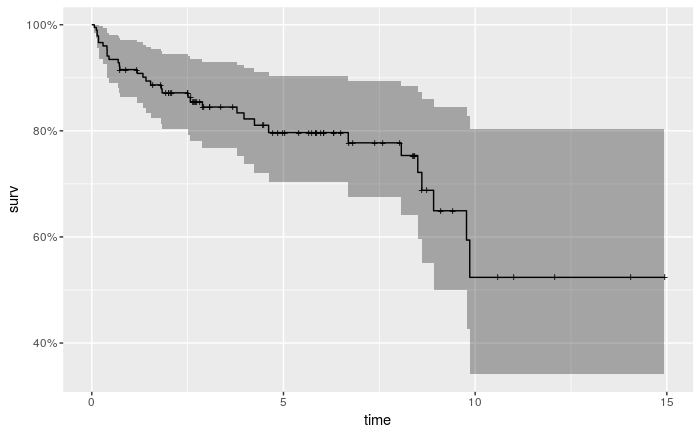

Ojo, la mediana no toca el 50%, por lo que da median = NA

```r
cox_fit_99
```

```
Call: survfit(formula = modelo_99)

      n  events  median 0.95LCL 0.95UCL
 106.00   34.00      NA    8.92      NA
```

```r
summary(cox_fit_99)
```

[output not shown]

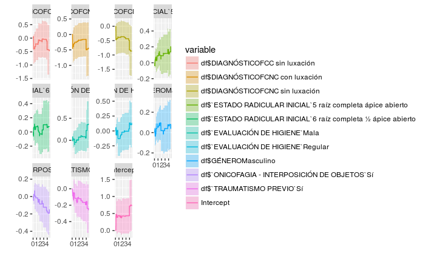

# Referencias

https://www.openintro.org/download.php?file=survival_analysis_in_R&referrer=/stat/surv.php

https://courses.nus.edu.sg/course/stacar/internet/st3242/handouts/notes3.pdf